# cmetcalf_PeerCommentary_reesehs_04

Cat Metcalf

2023-10-29

## Write a simple R function, Z.prop.test(), that can perform one- or two-sample Z-tests for proportion data, using the following guidelines:

```r
z.prop.test <- function( p1, n1, p2 = NULL, n2 = NULL, p0, alternative = c("two.sided", "less", "greater"), conf.levels = 0.95) {
  if(((n1*p1)> 5 )|| (n1*(1-p1) > 5)){
    print("non-normal distribution in one sample setting")
  }
  if((n2*p2)> 5 || n2*(1-p2) > 5){
    print("non-normal distribution in two sample setting")
  }
  if(is.null(p2) == TRUE || is.null(n2) == TRUE){
    z <- (p1-p0)/sqrt(p0 *(1-p0)/n1) #one sample z stat
    lower <- p1 - qnorm(0.95) * sqrt(p1 * (1 - p1)/n1)
    upper <- p1 + qnorm(0.95) * sqrt(p1 * (1 - p1)/n1)
    ci <- c(lower, upper) #confidence interval, is this correct? *C: i believe it is, yes!; whether it calculates correct within the function I am less sure about...
    ci
    if(alternative == "two.sided"){
       p <- 1 - pnorm(z, lower.tail = TRUE) + pnorm(z, lower.tail = FALSE) #two tailed p value
    }
    if(alternative == "less"){
      p <- pnorm(z, lower.tail = TRUE) #lower tailed p value
    }
    if(alternative == "greater"){
      p <- pnorm(z, lowertail = FALSE) #upper tail p value
    } #*C: don't forget the period in lower.tail above!

  }
  if(is.null(p2) == TRUE & is.null(n2) == TRUE){
   z <- (p1-p0)/sqrt(p0 *(1-p0)/n1) # one sample z stat
    if(alternative == "two.sided"){
       p <- 1 - pnorm(z, lower.tail = TRUE) + pnorm(z, lower.tail = FALSE)
    }
    if(alternative == "less"){
      p <- pnorm(z, lower.tail = TRUE)
    }
    if(alternative == "greater"){
      p <- pnorm(z, lowertail = FALSE)
    }
    lower <- p1 - qnorm(0.95) * sqrt(p1 * (1 - p1)/30)
    upper <- p1 + qnorm(0.95) * sqrt(p1 * (1 - p1)/30)
    ci <- c(lower, upper) #confidence interval, is this correct?
    ci
  }

  if(!is.null(p2) & !is.null(n2)){
    pstar <- ((p0)/(n1 + n2))
    z <- (p2 - p1 - p0)/sqrt((pstar * (1 - pstar)) * (1/n1) + (1/n2))
    p <- 1 - pnorm(z, lower.tail = TRUE) + pnorm(z, lower.tail = FALSE)

     upper <- (p1 -p2) + qnorm(0.95) + (sqrt((p1 * (1 - p1)/n1) + (p2 * (1-p2)/n2)))
     lower <- (p1 -p2) - qnorm(0.95) + (sqrt((p1 * (1 - p1)/n1) + (p2 * (1-p2)/n2)))
     ci <- c(lower, upper)
   # I literally have no idea how to do CI for a two sample test, I have looked everywhere.
  }
  list(z, p, ci)

  #unclear how to code this, any help would be much appreciated :') *C: i am not sure if this was referring to the whole chunk or the list function but if it is for list I can help! You can do return(list(estimate = z, p = p, ci=ci)), although you may have to play around with the variables a bit more since mine were a bit different when assigned! Hope that helps!
  }
```

*C: I know I had a lot of trouble with this and I would say you did an amazing job tackling everything! It is clear and makes sense each argument you are applying. While I am not sure how helpful my comments could be, I hoped they helped clear some of the function writing up :) ## The dataset from Kamilar and Cooper has in it a large number of variables related to life history and body size. For this exercise, the end aim is to fit a simple linear regression model to predict longevity (MaxLongevity_m) measured in months from species’ brain size (Brain_Size_Species_Mean) measured in grams. Do the following for both longevity~brain size and log(longevity)~log(brain size):

```r
library(ggplot2)
library(curl)
f <- curl("https://raw.githubusercontent.com/fuzzyatelin/fuzzyatelin.github.io/master/AN588_Fall23/KamilarAndCooperData.csv") #imports data from Kamilar/Cooper data
d <- read.csv(f, header = TRUE, sep = ",", stringsAsFactors = FALSE)  #reads data and creates data frame from it
head(d) #returns data frame
```

```
##               Scientific_Name          Family          Genus      Species
## 1 Allenopithecus_nigroviridis Cercopithecidae Allenopithecus nigroviridis
## 2         Allocebus_trichotis Cercopithecidae      Allocebus    trichotis
## 3           Alouatta_belzebul        Atelidae       Alouatta     belzebul
## 4             Alouatta_caraya        Atelidae       Alouatta       caraya
## 5            Alouatta_guariba        Atelidae       Alouatta      guariba
## 6           Alouatta_palliata        Atelidae       Alouatta     palliata
##   Brain_Size_Species_Mean Brain_Size_Female_Mean   Brain_size_Ref
## 1                   58.02                  53.70 Isler et al 2008
## 2                      NA                     NA
## 3                   52.84                  51.19 Isler et al 2008
## 4                   52.63                  47.80 Isler et al 2008
## 5                   51.70                  49.08 Isler et al 2008
## 6                   49.88                  48.04 Isler et al 2008
##   Body_mass_male_mean Body_mass_female_mean Mass_Dimorphism
```

[output cut: 62 more lines]

### Fit the regression model and, using {ggplot2}, produce a scatterplot with the fitted line superimposed upon the data. Append the the fitted model equation to your plot (HINT: use the function geom_text()).

```r
nl <- lm(data = d, MaxLongevity_m~Brain_Size_Species_Mean) #creates linear model
summary(nl)
```

```
##
## Call:
## lm(formula = MaxLongevity_m ~ Brain_Size_Species_Mean, data = d)
##
## Residuals:
##     Min      1Q  Median      3Q     Max
## -198.27  -61.92  -17.78   56.16  331.36
##
## Coefficients:
##                         Estimate Std. Error t value Pr(>|t|)
## (Intercept)             248.9523    11.1111   22.41   <2e-16 ***
## Brain_Size_Species_Mean   1.2180     0.1101   11.06   <2e-16 ***
## ---
## Signif. codes:  0 '***' 0.001 '**' 0.01 '*' 0.05 '.' 0.1 ' ' 1
##
## Residual standard error: 90.91 on 126 degrees of freedom
##   (85 observations deleted due to missingness)
## Multiple R-squared:  0.4928, Adjusted R-squared:  0.4887
## F-statistic: 122.4 on 1 and 126 DF,  p-value: < 2.2e-16
```

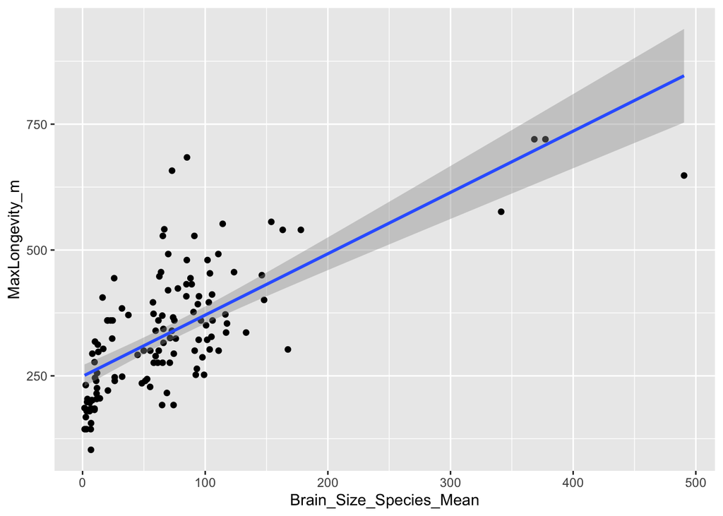

```r
g <- ggplot(data = d, aes(x = Brain_Size_Species_Mean, y = MaxLongevity_m)) + geom_point() + geom_smooth(method = "lm", formula = y ~ x) #need to add legend #creates plot of linear regression with 95% regression shaft outline
g
```

```r
beta1 <- cor(d$MaxLongevity_m, d$Brain_Size_Species_Mean, use = "complete.obs") * sd(d$MaxLongevity_m, na.rm = TRUE)/sd(d$Brain_Size_Species_Mean, na.rm = TRUE) #returns slope of linear regression
beta1
```

```
## [1] 1.138117
```

```r
beta0 <- mean(d$MaxLongevity_m, na.rm = TRUE) - beta1 * mean(d$Brain_Size_Species_Mean, na.rm = TRUE)
beta0 #gives intercept of linear regression
```

```
## [1] 249.815
```

```r
#how are you supposed to take the 90 percent CI for slope/beta1?

ci <- confint(nl, level = 0.90)  # using the results of lm() finds 90% confidence interval *C: nice job! I am pretty sure this does it
ci
```

```
##                                5 %      95 %
## (Intercept)             230.540738 267.36379
## Brain_Size_Species_Mean   1.035571   1.40041
```

```r
pe <- beta1 * 800 + beta0
pe #point estimate
```

```
## [1] 1160.308
```

```r
ci <- predict(nl, newdata = data.frame(Brain_Size_Species_Mean = 800), interval = "confidence",
    level = 0.9)  # confidence interval for a single value
ci
```

```
##        fit      lwr      upr
## 1 1223.345 1089.461 1357.228
```

```r
pi <- predict(nl, newdata = data.frame(Brain_Size_Species_Mean = 800), interval = "prediction",
    level = 0.9)  # prediction interval for a single value
pi
```

```
##        fit      lwr      upr
## 1 1223.345 1021.805 1424.884
```

```r
h_hat <- predict(nl, newdata = data.frame(Brain_Size_Species_Mean = d$Brain_Size_Species_Mean)) #generates predicted y values from the linear regression nl and based on x values of Brain size speices mean
df <- data.frame(cbind(d$Brain_Size_Species_Mean, d$MaxLongevity_m, h_hat))  #creates data frame of plot point and predicted points
names(df) <- c("x", "y", "yhat") #names the data columns
head(df)
```

```
##       x     y     yhat
## 1 58.02 276.0 319.6201
## 2    NA    NA       NA
## 3 52.84    NA 313.3109
## 4 52.63 243.6 313.0551
## 5 51.70    NA 311.9224
## 6 49.88 300.0 309.7056
```

```r
ci <- predict(nl, newdata = data.frame(Brain_Size_Species_Mean = d$Brain_Size_Species_Mean), interval = "confidence",
    level = 0.95, )  # predicts CI for a predicted vector of values
head(ci)
```

```
##        fit      lwr      upr
## 1 319.6201 303.5156 335.7245
## 2       NA       NA       NA
## 3 313.3109 296.9899 329.6319
## 4 313.0551 296.7238 329.3864
## 5 311.9224 295.5437 328.3011
## 6 309.7056 293.2275 326.1838
```

```r
df <- cbind(df, ci) #binds the list of CI values to dataframe
names(df) <- c("x", "y", "yhat", "CIfit", "CIlwr", "CIupr") #names the different columns containing CI values
head(df)
```

```
##       x     y     yhat    CIfit    CIlwr    CIupr
## 1 58.02 276.0 319.6201 319.6201 303.5156 335.7245
## 2    NA    NA       NA       NA       NA       NA
## 3 52.84    NA 313.3109 313.3109 296.9899 329.6319
## 4 52.63 243.6 313.0551 313.0551 296.7238 329.3864
## 5 51.70    NA 311.9224 311.9224 295.5437 328.3011
## 6 49.88 300.0 309.7056 309.7056 293.2275 326.1838
```

```r
pi <- predict(nl, newdata = data.frame(Brain_Size_Species_Mean = d$Brain_Size_Species_Mean), interval = "prediction",
    level = 0.9)  # predicts PI values for the predicted vector of values
head(pi)
```

```
##        fit      lwr      upr
## 1 319.6201 168.3750 470.8651
## 2       NA       NA       NA
## 3 313.3109 162.0496 464.5722
## 4 313.0551 161.7930 464.3172
## 5 311.9224 160.6567 463.1880
## 6 309.7056 158.4324 460.9789
```

```r
df <- cbind(df, pi)
names(df) <- c("x", "y", "yhat", "CIfit", "CIlwr", "CIupr", "PIfit", "PIlwr",
    "PIupr")
head(df)
```

```
##       x     y     yhat    CIfit    CIlwr    CIupr    PIfit    PIlwr    PIupr
## 1 58.02 276.0 319.6201 319.6201 303.5156 335.7245 319.6201 168.3750 470.8651
## 2    NA    NA       NA       NA       NA       NA       NA       NA       NA
## 3 52.84    NA 313.3109 313.3109 296.9899 329.6319 313.3109 162.0496 464.5722
## 4 52.63 243.6 313.0551 313.0551 296.7238 329.3864 313.0551 161.7930 464.3172
## 5 51.70    NA 311.9224 311.9224 295.5437 328.3011 311.9224 160.6567 463.1880
## 6 49.88 300.0 309.7056 309.7056 293.2275 326.1838 309.7056 158.4324 460.9789
```

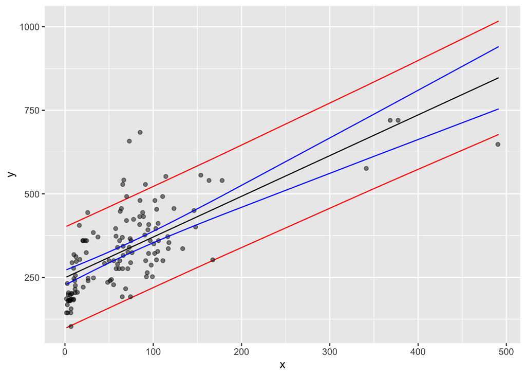

```r
g <- ggplot(data = df, aes(x = x, y = y))+ geom_line(data = df, aes(x = x, y = PIlwr), colour = "red") + geom_line(data = df, aes(x = x, y = PIupr), colour = "red") + geom_point(alpha = 1/2) + geom_line(aes(x = x, y = CIfit), colour = "black") + geom_line(aes(x = x, y = CIlwr), colour = "blue") + geom_line(aes(x = x, y = CIupr), colour = "blue") #adds PI upper and lower lines as well as CI upper, fit, and lower lines to plot of predicted data
g
```

*C: you did a really great job in this section commenting on each line of code to say what it gives you. i think it may benefit a reader who has no background if you explained what some variables mean, like yhat? Other than that, really excellent job adding everything to the plot and writing it out neatly.

```r
llm <- lm(data = d, log(d$MaxLongevity_m)~log(d$Brain_Size_Species_Mean)) #creates linear model
summary(llm)
```

```
##
## Call:
## lm(formula = log(d$MaxLongevity_m) ~ log(d$Brain_Size_Species_Mean),
##     data = d)
##
## Residuals:
##     Min      1Q  Median      3Q     Max
## -0.6955 -0.1750 -0.0097  0.1788  0.6084
##
## Coefficients:
##                                Estimate Std. Error t value Pr(>|t|)
## (Intercept)                     4.87895    0.06907   70.63   <2e-16 ***
## log(d$Brain_Size_Species_Mean)  0.23415    0.01781   13.15   <2e-16 ***
## ---
## Signif. codes:  0 '***' 0.001 '**' 0.01 '*' 0.05 '.' 0.1 ' ' 1
##
## Residual standard error: 0.2485 on 126 degrees of freedom
##   (85 observations deleted due to missingness)
## Multiple R-squared:  0.5784, Adjusted R-squared:  0.5751
## F-statistic: 172.9 on 1 and 126 DF,  p-value: < 2.2e-16
```

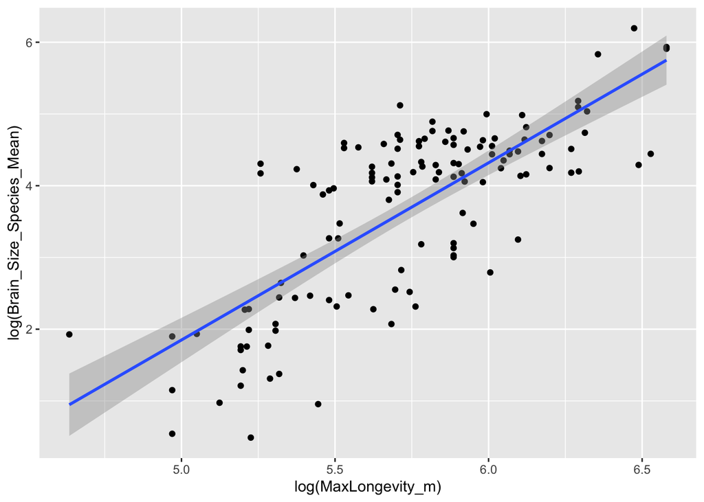

```r
lg <- ggplot(data = d, aes(x = log(MaxLongevity_m), y = log(Brain_Size_Species_Mean))) + geom_point() + geom_smooth(method = "lm", formula = y ~ x) #creates plot of linear regression with 95% regression shaft outline
lg
```

```r
beta1 <- cor(log(d$MaxLongevity_m), log(d$Brain_Size_Species_Mean), use = "complete.obs") * sd(log(d$MaxLongevity_m), na.rm = TRUE)/sd(log(d$Brain_Size_Species_Mean), na.rm = TRUE) #returns slope of linear regression
beta1
```

```
## [1] 0.2413857
```

```r
beta0 <- mean(log(d$MaxLongevity_m), na.rm = TRUE) - beta1 * mean(log(d$Brain_Size_Species_Mean), na.rm = TRUE)  #gives intercept of linear regression
beta0
```

```
## [1] 4.838191
```

```r
ci <- confint(llm, level = 0.90)  # using the results of lm(), confidence interval
ci
```

```
##                                      5 %      95 %
## (Intercept)                    4.7644934 4.9934084
## log(d$Brain_Size_Species_Mean) 0.2046396 0.2636595
```

```r
pe <- beta1 * 800 + beta0
pe #point estimate, maybe
```

```
## [1] 197.9468
```

```r
log.brain <- log(d$Brain_Size_Species_Mean)
#maybe this is how you do a point estimate?
logpe <- predict(llm, newdata = data.frame(log.brain = log(800)))
ci <- predict(llm, newdata = data.frame( Brain_Size_Species_Mean= log(800)), interval = "confidence",
    level = 0.9)  ## confidence interval for a single value(800)
ci #these don't work for some reason? *C: I was having trouble with this too, it only gave me the 95% conf interval, so not sure how to solve this unfortunately but interesting to see we are running into similary issues.
```

```
##          fit      lwr      upr
## 1   5.829783 5.791675 5.867891
## 2         NA       NA       NA
## 3   5.807885 5.770504 5.845267
## 4   5.806953 5.769598 5.844308
## 5   5.802778 5.765539 5.840018
## 6   5.794387 5.757357 5.831416
## 7   5.800182 5.763011 5.837354
## 8   5.818201 5.780501 5.855901
## 9   5.588116 5.546999 5.629233
## 10        NA       NA       NA
## 11  5.532501 5.487689 5.577313
## 12        NA       NA       NA
## 13        NA       NA       NA
## 14  5.540271 5.496024 5.584519
```

[output cut: 199 more lines]

```r
pi <- predict(llm, newdata = data.frame(Brain_Size_Species_Mean = log(800)), interval = "prediction",
    level = 0.9)
pi#these don't work for some reason?
```

```
##          fit      lwr      upr
## 1   5.829783 5.416322 6.243243
## 2         NA       NA       NA
## 3   5.807885 5.394491 6.221279
## 4   5.806953 5.393561 6.220344
## 5   5.802778 5.389397 6.216159
## 6   5.794387 5.381024 6.207749
## 7   5.800182 5.386807 6.213557
## 8   5.818201 5.404778 6.231624
## 9   5.588116 5.174367 6.001864
## 10        NA       NA       NA
## 11  5.532501 5.118369 5.946633
## 12        NA       NA       NA
## 13        NA       NA       NA
## 14  5.540271 5.126200 5.954343
```

[output cut: 199 more lines]

```r
h_hat <- predict(llm, newdata = data.frame(Brain_Size_Species_Mean = log(d$Brain_Size_Species_Mean)))
df <- data.frame(cbind(log(d$Brain_Size_Species_Mean)), (log(d$MaxLongevity_m)), h_hat)
names(df) <- c("x", "y", "yhat")
head(df)
```

```
##          x        y     yhat
## 1 4.060788 5.620401 5.829783
## 2       NA       NA       NA
## 3 3.967268       NA 5.807885
## 4 3.963286 5.495528 5.806953
## 5 3.945458       NA 5.802778
## 6 3.909620 5.703782 5.794387
```

```r
ci <- predict(llm, newdata = data.frame(Brain_Size_Species_Mean = log(d$Brain_Size_Species_Mean)), interval = "confidence",
    level = 0.9)
head(ci)
```

```
##        fit      lwr      upr
## 1 5.829783 5.791675 5.867891
## 2       NA       NA       NA
## 3 5.807885 5.770504 5.845267
## 4 5.806953 5.769598 5.844308
## 5 5.802778 5.765539 5.840018
## 6 5.794387 5.757357 5.831416
```

```r
df <- cbind(df, ci)
names(df) <- c("x", "y", "yhat", "CIfit", "CIlwr", "CIupr")
head(df)
```

```
##          x        y     yhat    CIfit    CIlwr    CIupr
## 1 4.060788 5.620401 5.829783 5.829783 5.791675 5.867891
## 2       NA       NA       NA       NA       NA       NA
## 3 3.967268       NA 5.807885 5.807885 5.770504 5.845267
## 4 3.963286 5.495528 5.806953 5.806953 5.769598 5.844308
## 5 3.945458       NA 5.802778 5.802778 5.765539 5.840018
## 6 3.909620 5.703782 5.794387 5.794387 5.757357 5.831416
```

```r
pi <- predict(llm, newdata = data.frame(Brain_Size_Species_Mean = log(d$Brain_Size_Species_Mean)), interval = "prediction",
    level = 0.9)
head(pi)
```

```
##        fit      lwr      upr
## 1 5.829783 5.416322 6.243243
## 2       NA       NA       NA
## 3 5.807885 5.394491 6.221279
## 4 5.806953 5.393561 6.220344
## 5 5.802778 5.389397 6.216159
## 6 5.794387 5.381024 6.207749
```

```r
df <- cbind(df, pi)
names(df) <- c("x", "y", "yhat", "CIfit", "CIlwr", "CIupr", "PIfit", "PIlwr",
    "PIupr")
head(df)
```

```
##          x        y     yhat    CIfit    CIlwr    CIupr    PIfit    PIlwr
## 1 4.060788 5.620401 5.829783 5.829783 5.791675 5.867891 5.829783 5.416322
## 2       NA       NA       NA       NA       NA       NA       NA       NA
## 3 3.967268       NA 5.807885 5.807885 5.770504 5.845267 5.807885 5.394491
## 4 3.963286 5.495528 5.806953 5.806953 5.769598 5.844308 5.806953 5.393561
## 5 3.945458       NA 5.802778 5.802778 5.765539 5.840018 5.802778 5.389397
## 6 3.909620 5.703782 5.794387 5.794387 5.757357 5.831416 5.794387 5.381024
##      PIupr
## 1 6.243243
## 2       NA
## 3 6.221279
## 4 6.220344
## 5 6.216159
## 6 6.207749
```

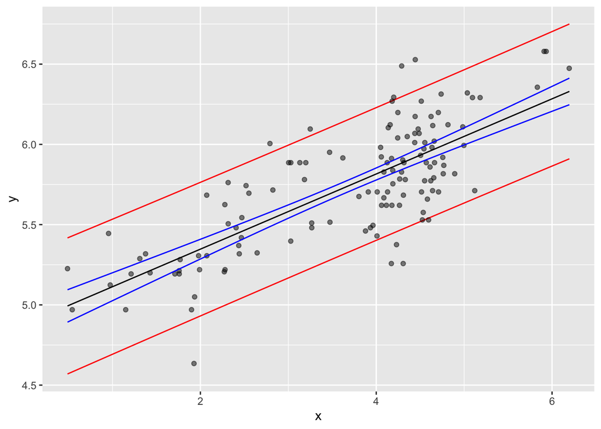

```r
g <- ggplot(data = df, aes(x = x, y = y))+ geom_line(data = df, aes(x = x, y = PIlwr), colour = "red") + geom_line(data = df, aes(x = x, y = PIupr), colour = "red") + geom_point(alpha = 1/2) + geom_line(aes(x = x, y = CIfit), colour = "black") + geom_line(aes(x = x, y = CIlwr), colour = "blue") + geom_line(aes(x = x, y = CIupr), colour = "blue")
g
```

*C: You did such an excellent job with all of this considering the challenge it gave all of us. Your code is clear, concise, and seems to work relatively smoothly as well. I am sorry if my comments were not super helpful in adding much, as I had trouble with this assignment but I think you really met most of the goals despite the obstacles still faced. Great job! Challenges: 1. Figuring out how to do confidence intervals for each type is confusing 2.I still don’t know how to do a point estimate or how to do the test hypotheses? 3.There are supposed to be two models, what are they, I’m very confused?